# Application Activity

Unit 1 Review

Author

Nathan Lunceford

# Assessment Objectives

- Apply the 3 rules of probability in different scenarios
- Describe the 5 steps of the statistical process
- Differentiate between an observational study and an experiment
- Differentiate between a population and a sample
- Describe the 4 random sampling schemes
- Explain importance of random sampling
- Distinguish between quantitative and categorical variables
- Create graphical summaries of data (boxplots, histograms) and be able to make conclusions based on the graphs
- Create numerical summaries of data (mean, sd, 5 number summary, percentiles) and compare groups (centers, spreads)
- Distinguish between a parameter and a statistic
- Determine the 5 number summary from a boxplot
- State the properties of a normal distribution
- Calculate the z-score for an individual from a normal population with mean, $\mu$, and std. dev, $\sigma$
- Calculate probabilities (>, <, between) of certain values given $\mu$ and $\sigma$
- Describe the concept of a sampling distribution of the sample mean
- State the Central Limit Theorem
- Determine the mean of the sampling distribution of the sample mean given $\mu$ and $\sigma$
- Determine the std. dev. of the sampling distribution of the sample mean given $\mu$ and $\sigma$
- Determine the *shape* of the sampling distribution given a sample size, n, and $\mu$ and $\sigma$
- State the Law of Large Numbers

# Design the Study

You and a colleague are interested in studying the relationship between social media use and mental health among youth ages 18-24. You decide to use the Psychological Wellbeing Scale (PWB) developed by Stanford University as your metric for comparison (the response variable).

**Q1.1:**

List 5 factors (explanatory variables) related to social media use that might impact Wellbeing.

Include whether or not the factors are quantitative or categorical (include at least one of each):

1. **Time spent on social media (Quantitative):** The total number of hours per day spent on social media platforms.
2. **Type of social media platforms used (Categorical):** Different platforms like Facebook, Instagram, Twitter, TikTok, etc.
3. **Purpose of social media use (Categorical):** Reasons for using social media, such as socializing, news, entertainment, education, etc.
4. **Number of social media accounts (Quantitative):** The total number of different social media accounts a person maintains.
5. **Engagement in social media activities (Quantitative):** The frequency of activities such as posting, liking, commenting, and sharing content.

**Q1.2:**

What is the population of the study?

**Youth ages 18-24**

**Q1.3:**

Suppose you are *not* resource limited. Briefly describe the sampling scheme you would use and why you would choose it to best represent the population:

**I would use stratified sampling to ensure that different subgroups within the population are adequately represented.**

**Q1.4:**

Give a brief description of the other 3 types of sampling schemes and explain why they don’t make sense in this situation:

1. **Simple Random Sampling (SRS)**
   - Reason it doesn’t make sense: While SRS is straightforward and reduces bias, it may not ensure that all key subgroups within the population are adequately represented.
2. **Systematic Sampling**
   - Reason it doesn’t make sense: Systematic sampling might introduce periodicity biases.
3. **Cluster Sampling**
   - Reason it doesn’t make sense: Cluster sampling can introduce cluster-specific biases and may not be efficient if clusters (e.g., specific universities or cities) have unique social media usage patterns that aren’t representative of the broader population.

**Q1.5:**

Suppose it is impractical to sample from the population described in Q1.2. What population might be more feasible to sample from?

**A more feasible population to sample from might be college students aged 18-24.**

**Q1.6:**

How would modifying the population of interest impact your sampling scheme?

**Modifying the population of interest would require changing the groups for sampling and adjusting the sample size.**

**Q1.7:**

Suppose you sent out a Facebook survey to all of your followers and asked them to respond if they are in your target demographic. How might this impact the conclusions of your study?

**Sending a Facebook survey to your followers could introduce self-selection bias which could result in a non-representative sample.**

# Describe/Summarize the Data

For this section you will program in R. Don’t forget to load the libraries first:

## Housing Prices in Rexburg

You are interested housing prices in Rexburg, Idaho. Load the housing data and respond to the following questions.

```r
# Load the data:
housing <- import('https://github.com/byuistats/Math221D_Cannon/raw/master/Data/MadisonCountyRealEstate.xlsx') %>% select(ListPrice, Bedrooms)
```

**Q2.1:**

Create a histogram of list price.

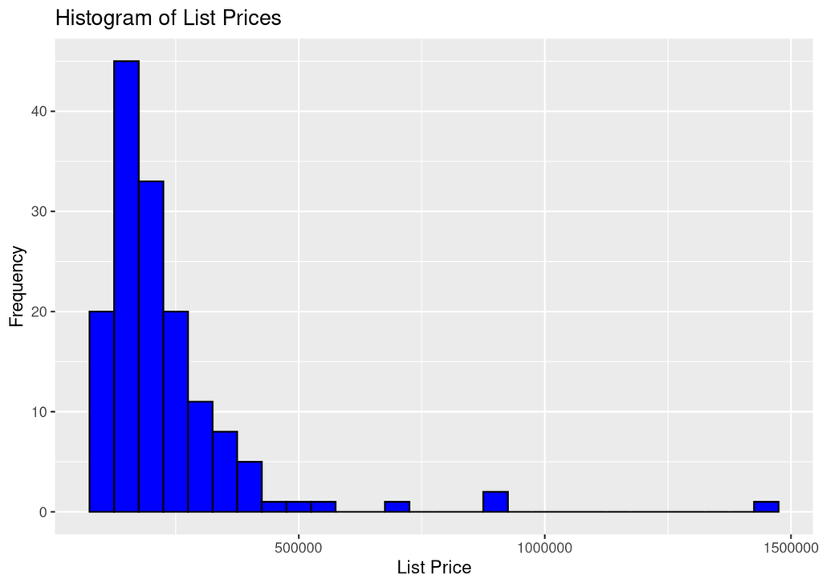

```r
ggplot(housing, aes(x = ListPrice)) +
  geom_histogram(binwidth = 50000, fill = "blue", color = "black") +
  labs(title = "Histogram of List Prices", x = "List Price", y = "Frequency")
```

What is the shape of the distribution of list prices for homes in Rexburg.

**The shape of the distribution of list prices for homes in Rexburg is right-skewed, with most prices clustered at the lower end and a few higher-priced homes.**

**Q2.2:**

Calculate the mean, standard deviation, 5 number summary and sample size of housing prices for each number of bedrooms.

```r
housing_summary <- favstats(ListPrice ~ Bedrooms, data = housing)
knitr::kable(housing_summary)
```

| Bedrooms | min | Q1 | median | Q3 | max | mean | sd | n | missing |
| --- | --- | --- | --- | --- | --- | --- | --- | --- | --- |
| 2 | 96900 | 108175 | 117450 | 129675 | 160000 | 119984.6 | 15206.23 | 26 | 0 |
| 3 | 109900 | 142150 | 184700 | 213650 | 499999 | 199120.8 | 79099.36 | 48 | 0 |
| 4 | 119900 | 157000 | 174900 | 228000 | 369000 | 200642.1 | 71075.72 | 19 | 0 |
| 5 | 137000 | 189900 | 219900 | 275000 | 924500 | 250483.8 | 131359.88 | 37 | 0 |
| 6 | 179900 | 281500 | 319000 | 364000 | 699000 | 340740.0 | 118103.19 | 15 | 0 |
| 7 | 199000 | 454675 | 717450 | 1040000 | 1475000 | 777225.0 | 545108.00 | 4 | 0 |

What is the standard deviation of homes with 3 bedrooms?

**The standard deviation of homes with 3 bedrooms is $79,099.36.**

How do you interpret that number?

**The standard deviation indicates that the list prices of 3-bedroom homes in Rexburg vary by approximately $79,099.36 around the mean price. This means that the prices of these homes are kind of spread out over a wide range.**

**Q2.3:**

What is the maximum value home price for a 2 bedroom house?

**$160,000**

Suppose there was a typo in the data and the maximum price for a 2 bedroom house was accidentally entered as $1,700,000.

How would the median change?

**The median would remain unchanged, as it is not affected by extreme values.**

How would the mean change?

**The mean would increase, as it is sensitive to extreme values.**

How would the standard deviation change?

**The standard deviation would increase, as it measures the spread of the data and would be affected by the large value.**

**Q2.4:**

Create a side-by-side boxplot of housing prices for each group. **Modify the color scheme so that each boxplot is a different color**.

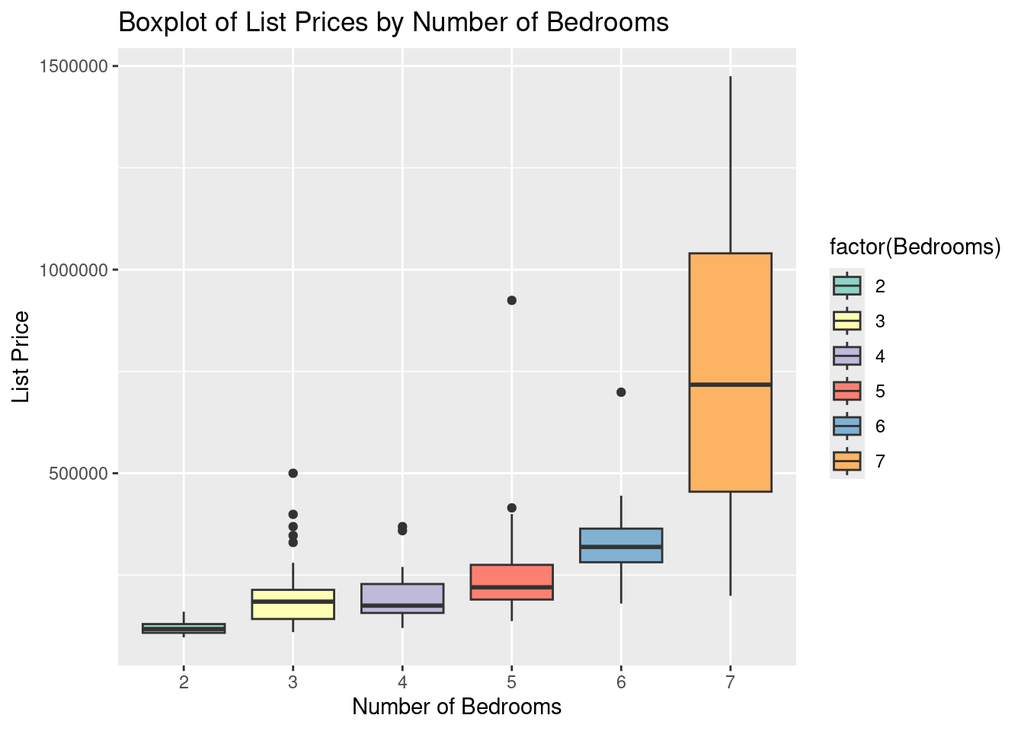

```r
ggplot(housing, aes(x = factor(Bedrooms), y = ListPrice, fill = factor(Bedrooms))) +
  geom_boxplot() +
  scale_fill_brewer(palette = "Set3") +
  labs(title = "Boxplot of List Prices by Number of Bedrooms", x = "Number of Bedrooms", y = "List Price")
```

What trends do you notice?

**In general, the more bedrooms a house has the more the house costs. The difference in price between 4 and 3 bedroom homes is minimal.**

Why might the box plot for 7 bedroom homes look so different than the others?

**The box plot for 7-bedroom looks different due to fewer data points and them being outliers.**

# Probability

## Hair Color

Brother Cannon has been collecting hair color data about his students for the last several semesters. The proportion of students with each hair color are as follows:

(run the following R chunk to see the table more clearly)

```r
knitr::kable(tibble(Red="???", Brown=.37, Black=.35, Blond = .22, Other=.02))
```

| Red | Brown | Black | Blond | Other |
| --- | --- | --- | --- | --- |
| ??? | 0.37 | 0.35 | 0.22 | 0.02 |

**Q3.1:**

What percent of Brother Cannon’s students have red hair?

**Four percent of students have red hair.**

**Q3.2:**

What’s the probability that a randomly selected student has either black or brown hair?

**The probability that a randomly selected student has either black or brown hair is 72%.**

## Social Media Use

**Q4.1:**

The number of hours students spend on social media a week is known to be left skewed with a mean of 12 hours and a standard deviation 1.5.

Suppose we take a random sample of 50 students and calculate the average time they spend on social media.

**Q4.2:**

What is the mean of the distribution of sample means for this sample size?

**The mean is the same as the population mean: 12 hours.**

**Q4.3:**

What is the standard deviation of sample means for this sample size?

**The standard deviation of sample means for this sample size would be about .212.**

**Q4.4:**

What is the shape of the distribution of sample means for this sample size and why?

**The distribution of sample means will be approximately normal due to the Central Limit Theorem.**

## Faculty Salaries

Faculty salaries at a university are known to be normally distributed with a mean of $108,552 and a standard deviation of $13,277.

You randomly sample n=15 faculty members and calculate their average salary.

**Q5.1:**

What is the mean of the distribution of sample means for this sample size?

**The mean is the same as the population mean: $108,552.**

**Q5.2:**

What is the standard deviation of sample means for this sample size?

**The standard deviation of the sample means for a sample size of 15 is approximately $3428.11**

**Q5.3:**

What is the shape of the distribution of sample means for this sample size and why?

**The shape of the distribution of sample means for this sample size is approximately normal because the population from which the samples are drawn is normally distributed.**

## Normal Probability Calculations

High blood pressure is strongly associated with a host of diseases and increases risk of cardiac arrest (hear attacks) in older patients.

Suppose that systolic blood pressure in the US is normally distributed with a mean = 128 and a standard deviation of 11.

**Q6.1:**

What is the probability that a randomly selected person in the US has a systolic blood pressure of greater than 145?

**6.11%**

**Q6.2**

What is the probability that a randomly selected group of 10 people in the US have an *average* blood pressure less than 130?

**71.73%**

**Q6.3:**

Your doctor says you’re in great shape, and that you are in the 20th percentile for systolic blood pressure.

What does it mean that you are the 20th percentile?

**Being in the 20th percentile means that your systolic blood pressure is lower than 80% of the population.**

What is your blood pressure?

**My blood pressure would be approximately 118.74.**